# Regression and model validation

## Reading the data in to R

Load GGally (and ggplot2), set the working directory to the IODS folder and read in the local tab separated copy of the file

```r
library(GGally)
setwd("~/Work/IODS-project")
analysis2014 <- read.table("data/analysis2014.txt", sep="\t", header=TRUE)
```

## The structure and the dimensions of the data

```r
str(analysis2014)
```

```
## 'data.frame':    166 obs. of  7 variables:
##  $ Age     : int  53 55 49 53 49 38 50 37 37 42 ...
##  $ Attitude: int  37 31 25 35 37 38 35 29 38 21 ...
##  $ Points  : int  25 12 24 10 22 21 21 31 24 26 ...
##  $ gender  : Factor w/ 2 levels "F","M": 1 2 1 2 2 1 2 1 2 1 ...
##  $ deep    : num  3.58 2.92 3.5 3.5 3.67 ...
##  $ surf    : num  2.58 3.17 2.25 2.25 2.83 ...
##  $ stra    : num  3.38 2.75 3.62 3.12 3.62 ...
```

```r
dim(analysis2014)
```

```
## [1] 166   7
```

## Data overview

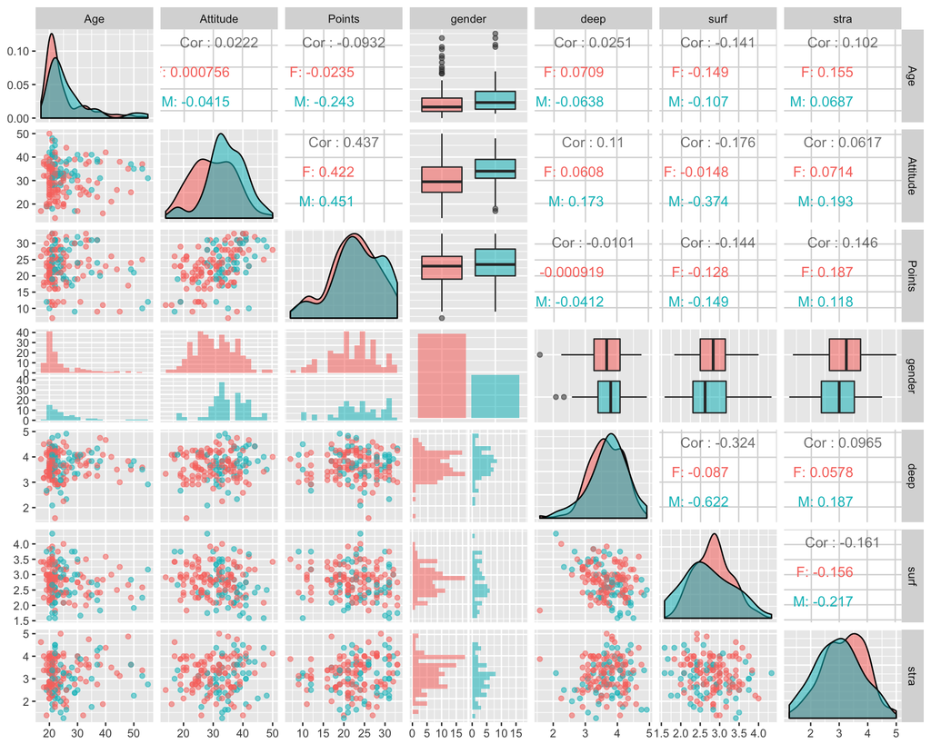

```r
ggpairs(analysis2014, mapping = aes(col=gender, alpha=0.3), lower = list(combo = wrap("facethist", bins = 20)))
```

```r
summary(analysis2014)
```

```
##       Age           Attitude         Points      gender       deep
##  Min.   :17.00   Min.   :14.00   Min.   : 7.00   F:110   Min.   :1.583
##  1st Qu.:21.00   1st Qu.:26.00   1st Qu.:19.00   M: 56   1st Qu.:3.333
##  Median :22.00   Median :32.00   Median :23.00           Median :3.667
##  Mean   :25.51   Mean   :31.43   Mean   :22.72           Mean   :3.680
##  3rd Qu.:27.00   3rd Qu.:37.00   3rd Qu.:27.75           3rd Qu.:4.083
##  Max.   :55.00   Max.   :50.00   Max.   :33.00           Max.   :4.917
##       surf            stra
##  Min.   :1.583   Min.   :1.250
##  1st Qu.:2.417   1st Qu.:2.625
##  Median :2.833   Median :3.188
##  Mean   :2.787   Mean   :3.121
##  3rd Qu.:3.167   3rd Qu.:3.625
##  Max.   :4.333   Max.   :5.000
```

Most of the variables have a close to normal distribution, except age that is closer to poisson distribution. There’s twice as much women in the data set. The strongest correlation can be seen between Attitude and Points.

## Regression model

```r
lm1 <- lm(Points~Age+gender+Attitude, data=analysis2014)
summary(lm1)
```

```
##
## Call:
## lm(formula = Points ~ Age + gender + Attitude, data = analysis2014)
##
## Residuals:
##      Min       1Q   Median       3Q      Max
## -17.4590  -3.3221   0.2186   4.0247  10.4632
##
## Coefficients:
##             Estimate Std. Error t value Pr(>|t|)
## (Intercept) 13.42910    2.29043   5.863 2.48e-08 ***
## Age         -0.07586    0.05367  -1.414    0.159
## genderM     -0.33054    0.91934  -0.360    0.720
## Attitude     0.36066    0.05932   6.080 8.34e-09 ***
## ---
## Signif. codes:  0 '***' 0.001 '**' 0.01 '*' 0.05 '.' 0.1 ' ' 1
##
## Residual standard error: 5.315 on 162 degrees of freedom
## Multiple R-squared:  0.2018, Adjusted R-squared:  0.187
## F-statistic: 13.65 on 3 and 162 DF,  p-value: 5.536e-08
```

```r
lm2 <- lm(Points~Attitude, data=analysis2014)
summary(lm2)
```

```
##
## Call:
## lm(formula = Points ~ Attitude, data = analysis2014)
##
## Residuals:
##      Min       1Q   Median       3Q      Max
## -16.9763  -3.2119   0.4339   4.1534  10.6645
##
## Coefficients:
##             Estimate Std. Error t value Pr(>|t|)
## (Intercept) 11.63715    1.83035   6.358 1.95e-09 ***
## Attitude     0.35255    0.05674   6.214 4.12e-09 ***
## ---
## Signif. codes:  0 '***' 0.001 '**' 0.01 '*' 0.05 '.' 0.1 ' ' 1
##
## Residual standard error: 5.32 on 164 degrees of freedom
## Multiple R-squared:  0.1906, Adjusted R-squared:  0.1856
## F-statistic: 38.61 on 1 and 164 DF,  p-value: 4.119e-09
```

In the model with age, gender and attitude as explanatory variables, only attitude was significantly affecting the points. Age or gender do not affect the points. In the final model the attitude has significant positive correlation with points

## Model diagnostics

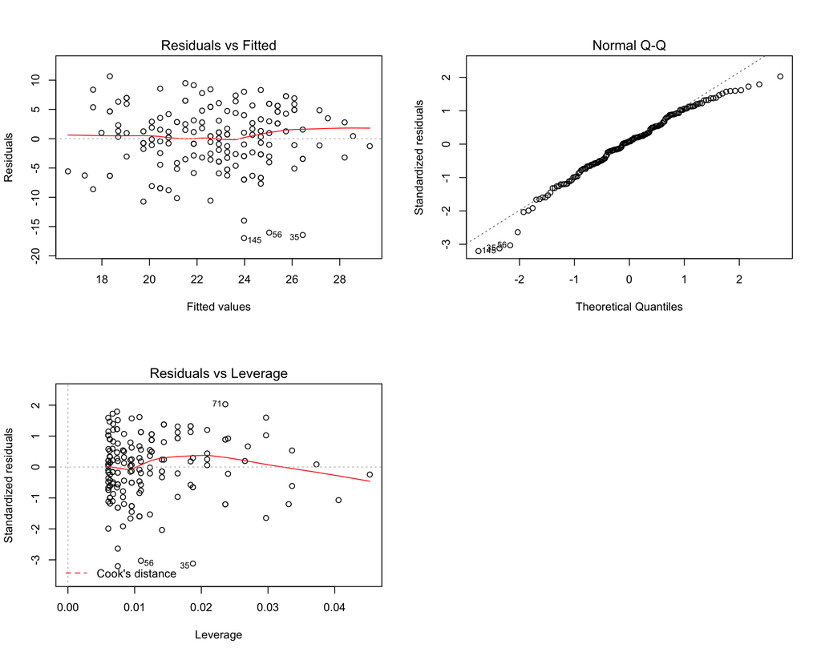

```r
par(mfrow=c(2,2))
plot(lm2, which = c(1,2,5))
```

It can be seen from the diagnostic plots for the second model that there’s no pattern in the residuals, so we have constant variance. There are some possible outliers as shown in the plot. The residuals have a fairly normal distribution, again excluding the some possible outliers. Also the leverage plot shows that few points could be outliers in this data set.